# 4: Extracting future farm temperatures

FAO Climate Change Risks to Fed Mariculture

Author

Tormey Reimer

Published

18 November 2026

← Previous: All species parameters

Next: Test production →

# Overview

Once farm locations are assigned, temperatures need to be extracted into the future.

## Correcting temperatures

Bias correction uses the decadal mean from 2015–2024 for both datasets (`data-prep-scripts/correcting-temperatures.R`). The change in temperature per grid cell from the CMIP projections is used as a delta applied on top of the contemporary NASA SST data (i.e. `corrected = CMIP_future − CMIP_meanyear + NASA_meanyear`). February 29 dates in leap years are handled by interpolating the adjacent meanyear layers (DOY 059 and DOY 060) with equal weights. The corrected rasters are saved to `bigdata_path/ESGF/EC-Earth3P-HR/projected_adjusted/`.

**List the projected_adjusted files to check we’re getting them from the correct place**

```r
tos_rast_fnms <- file.path(bigdata_path, "ESGF", "EC-Earth3P-HR", "projected_adjusted") %>%
  list.files(full.names = T) %>%
  sort()

# Use just one raster for cell assignment
tos_rast <- rast(tos_rast_fnms[1])
```

# Get farm locations

**Load saved data for summarising**

```r
assigned_farms <- file.path(prepdata_path, "assigned_farms.qs") %>%
  qs_read()
```

## Get farm locations in temperature rasters

Once we have a representative corrected global temperature raster, we can extract the locations we actually want - the farms that have been assigned for use in this analysis. The first step is to assign each farm location a cell number (or several cell numbers) within the temperature raster stack.

**Assign cell(s) to each farm and create a lookup table for future temperature extraction**

```r
farm_points <- assigned_farms %>%
  vect()

# Attempt to extract the cell numbers dirrectly underneath assigned farms
farm_cells <- terra::extract(tos_rast, farm_points, cells = T, ID = F) %>%
  rename(focal_cell = cell)
farm_cells$farm_ID <- farm_points$farm_ID

simple_assigned <- farm_cells %>%
  filter(!is.na(focal_mean))

message(sprintf("%i of %i farm IDs have a simple cell extracted (%0.1f%%).",
  nrow(simple_assigned),
  nrow(farm_cells),
  100*nrow(simple_assigned)/nrow(farm_cells)
))
```

```
11882 of 15916 farm IDs have a simple cell extracted (74.7%).
```

**Assign cell(s) to each farm and create a lookup table for future temperature extraction**

```r
# Look at the 4 surrounding cells of each missing cell to try and find a viable temperature
still_missing_1 <- farm_cells %>%
  filter(is.na(focal_mean))

neighbours_4 <- terra::adjacent(tos_rast, cells = still_missing_1$focal_cell, directions = 4)
neighbours_4 <- split(neighbours_4, row(neighbours_4)) |> unname()

still_missing_1 <- still_missing_1 %>%
  mutate(neighbours_4 = neighbours_4, new_cells = NA)

still_missing_1 <- still_missing_1 %>%
  mutate(
    new_cells = lapply(neighbours_4, function(nb) {
      cells <- unlist(nb)
      temps <- terra::extract(tos_rast, cells)
      if (any(!is.na(temps$focal_mean))) cells else NA
    })
  )

assigned_4 <- still_missing_1 %>%
  filter(!is.na(new_cells))

message(sprintf("%i of %i remaining farm IDs have cells from the 4 cardinal directions around extracted (%0.1f%%).",
  nrow(assigned_4),
  nrow(still_missing_1),
  100*nrow(assigned_4)/nrow(still_missing_1))
)
```

```
3146 of 4034 remaining farm IDs have cells from the 4 cardinal directions around extracted (78.0%).
```

**Assign cell(s) to each farm and create a lookup table for future temperature extraction**

```r
# Look at the 8 surrounding cells of each missing cell to try and find a viable temperature
still_missing_2 <- still_missing_1 %>%
  filter(is.na(new_cells))

neighbours_8 <- terra::adjacent(tos_rast, cells = still_missing_2$focal_cell, directions = 8)
neighbours_8 <- split(neighbours_8, row(neighbours_8)) |> unname()

still_missing_2 <- still_missing_2 %>%
  mutate(neighbours_8 = neighbours_8)

still_missing_2 <- still_missing_2 %>%
  mutate(
    new_cells = lapply(neighbours_8, function(nb) {
      cells <- unlist(nb)
      temps <- terra::extract(tos_rast, cells)
      if (any(!is.na(temps$focal_mean))) cells else NA
    })
  )

assigned_8 <- still_missing_2 %>%
  filter(!is.na(new_cells))

message(sprintf("%i of %i remaining farm IDs have cells from the 8 directions around extracted (%0.1f%%).",
  nrow(assigned_8),
  nrow(still_missing_2),
  100*nrow(assigned_8)/nrow(still_missing_2)
))
```

```
336 of 888 remaining farm IDs have cells from the 8 directions around extracted (37.8%).
```

**Assign cell(s) to each farm and create a lookup table for future temperature extraction**

```r
# Let's expand the search
still_missing_3 <- still_missing_2 %>%
  filter(is.na(new_cells))

still_missing_3 <- still_missing_3 %>%
  mutate(
    new_cells = lapply(neighbours_4, function(nb) {
      nb_all <- terra::adjacent(tos_rast, cells = nb, directions = 8) %>% as.vector() %>% unique()
      nb_all <- terra::adjacent(tos_rast, cells = nb_all, directions = 4) %>% as.vector() %>% unique()
      temps <- terra::extract(tos_rast, nb_all)
      if (any(!is.na(temps$focal_mean))) nb_all else NA
    })
  )

assigned_exp <- still_missing_3 %>%
  filter(!is.na(new_cells))

message(sprintf("%i of %i remaining farm IDs have cells from the expanded cell radius around extracted (%0.1f%%).",
  nrow(assigned_exp),
  nrow(still_missing_3),
  100*nrow(assigned_exp)/nrow(still_missing_3))
)
```

```
420 of 552 remaining farm IDs have cells from the expanded cell radius around extracted (76.1%).
```

**Assign cell(s) to each farm and create a lookup table for future temperature extraction**

```r
message(sprintf("There are %i farm_IDs still remaining.", still_missing_3 %>% filter(is.na(new_cells)) %>% nrow()))
```

```
There are 132 farm_IDs still remaining.
```

**Show the missing farms and their nearest neighbour**

```
<SpatRaster> resampled to 5e+05 cells.
```

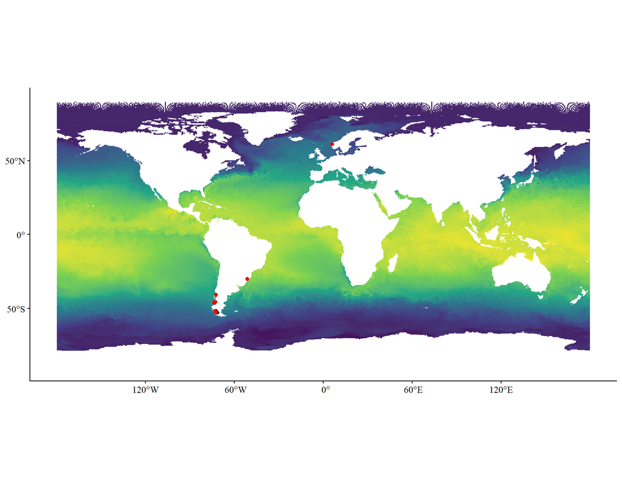

Figure 1

```r
missing_farms <- still_missing_3 %>%
  filter(is.na(new_cells)) %>%
  pull(farm_ID)

farm_points_missing <- assigned_farms %>% # includes a geometry column
  mutate(is_missing = case_when(farm_ID %in% missing_farms ~ T, T ~ F)) %>%
  select(farm_ID, is_missing) %>%
  mutate(type = "missing")

missing <- farm_points_missing %>% filter(is_missing)
non_missing <- farm_points_missing %>% filter(!is_missing)

nearest_idx <- sf::st_nearest_feature(missing, non_missing)
nearst_non_missing <- non_missing[nearest_idx, ] %>%
  mutate(type = "nonmissing")

paired <- rbind(missing, nearst_non_missing)
duplicated <- cbind(
  st_drop_geometry(missing),
  nearst_non_missing %>% st_drop_geometry() %>% rename(dup_farm_ID = farm_ID) %>% select(dup_farm_ID)
) %>%
  select(farm_ID, dup_farm_ID)

ggplot() +
  geom_spatraster(data = tos_rast) +
  geom_sf(data = paired, aes(geometry = geometry, colour = as.factor(type))) +
  scale_fill_viridis_c(na.value = NA) +
  scale_color_manual(values = c("missing" = "black", "nonmissing" = "red")) +
  prettyplot() + coord_sf()
```

**Combine cell assignments**

```r
# The simple assignments
assigned_farms_cells <- assigned_farms %>%
  left_join(
    simple_assigned %>%
      mutate(focal_cells = as.list(focal_cell)) %>%
      select(focal_cells, farm_ID),
    by = "farm_ID"
  )

# The 4-way assignments
geometry <- sf::st_geometry(assigned_farms_cells) # so annoying
assigned_farms_cells <- assigned_farms_cells %>%
  sf::st_drop_geometry() %>%
  rows_update(
    assigned_4 %>%
      select(farm_ID, new_cells) %>%
      rename(focal_cells = new_cells),
    by = "farm_ID"
  ) %>%
  sf::st_set_geometry(geometry)

# The 8-way assignments
geometry <- sf::st_geometry(assigned_farms_cells) # so annoying
assigned_farms_cells <- assigned_farms_cells %>%
  sf::st_drop_geometry() %>%
  rows_update(
    assigned_8 %>%
      select(farm_ID, new_cells) %>%
      rename(focal_cells = new_cells),
    by = "farm_ID"
  ) %>%
  sf::st_set_geometry(geometry)

# The expanded assignments
geometry <- sf::st_geometry(assigned_farms_cells) # so annoying
assigned_farms_cells <- assigned_farms_cells %>%
  sf::st_drop_geometry() %>%
  rows_update(
    assigned_exp %>%
      select(farm_ID, new_cells) %>%
      rename(focal_cells = new_cells),
    by = "farm_ID"
  ) %>%
  sf::st_set_geometry(geometry)

# The ones copying from neighbours
geometry <- sf::st_geometry(assigned_farms_cells) # so annoying
assigned_farms_cells <- assigned_farms_cells %>%
  sf::st_drop_geometry() %>%
  rows_update(
    duplicated %>% mutate(focal_cells = as.list(as.numeric(dup_farm_ID))) %>% select(farm_ID, focal_cells),
    by = "farm_ID"
  ) %>%
  sf::st_set_geometry(geometry)

# Finally check for any missing - should be none!
assigned_farms_cells %>%
  filter(length(focal_cells) == 0)
```

```
Simple feature collection with 0 features and 11 fields
Geometry type: POINT
Bounding box:  xmin: NA ymin: NA xmax: NA ymax: NA
Geodetic CRS:  WGS 84
# A tibble: 0 × 12
# ℹ 12 variables: ISO3_Code <chr>, country <chr>, species_group <chr>,
#   farm_ID <dbl>, F_CODE <dbl>, source <chr>, model_name <chr>,
#   prod_perfarm <dbl>, value <dbl>, n_farms <int>, focal_cells <list>,
#   geometry <POINT [°]>
```

**Combine cell assignments**

```r
qs_save(assigned_farms_cells, file.path(prepdata_path, "assigned_farms_focal_cells.qs"))
```

# Extract future temperatures

**Prep for temperature extraction**

```r
# quick cleanup
rm(geometry, still_missing_2, still_missing_3, assigned_4, assigned_8, assigned_exp, simple_assigned, farm_points_missing, non_missing, missing, paired, duplicated, still_missing_1, nearst_non_missing)
gc()
```

```
          used  (Mb) gc trigger  (Mb) max used  (Mb)
Ncells 3015615 161.1    6447544 344.4  4515770 241.2
Vcells 9594481  73.3   34320708 261.9 34320708 261.9
```

**Prep for temperature extraction**

```r
# Where to save the final temperature files?
farm_temp_outputs <- file.path(prepdata_path, "assigned_farms_alltemps")
dir.create(farm_temp_outputs, showWarnings = F)

# Group the projected-adjusted temperature raster files by year
tos_rast_fnms_ls <- tibble(
  path = tos_rast_fnms,
  date = as.Date(str_extract(basename(tos_rast_fnms), "\\d{4}-\\d{2}-\\d{2}")),
  year = year(date)
)
tos_rast_fnms_ls <- split(tos_rast_fnms_ls, tos_rast_fnms_ls$year)
```

**Split focal cells by farm source (mapped vs extracted)**

```r
lookup_dir <- file.path(data_path, "intermediates", "farm_focal_lookup_files")
dir.create(lookup_dir, showWarnings = F, recursive = T)

# "mapped" farms have fixed locations and only change in whether they're included.
# "extracted" farms can move at any time, so their cells are always re-extracted.
mapped_cells <- assigned_farms_cells %>%
  filter(source == "mapped") %>%
  pull(focal_cells) %>%
  unlist() %>%
  unique()

extracted_cells <- assigned_farms_cells %>%
  filter(source == "extracted") %>%
  pull(focal_cells) %>%
  unlist() %>%
  unique()

# Helper: extract a set of cells from one year's raster stack and save as a lookup table
extract_year_cells <- function(yr_fnms, cells, out_file) {
  tos_stack <- rast(yr_fnms$path)
  names(tos_stack) <- yr_fnms$date
  extracted <- terra::extract(tos_stack, cells)
  extracted$cell <- cells
  qs2::qs_save(extracted, out_file)
  invisible(out_file)
}
```

This next cell extracts all temperatures in each year for every focal cell. This avoids having to do multiple extracts of the surface temperature rasters. Each year ends up with up to three lookup files:

- `extracted_<year>.qs` – the main file, created from all mapped farm cells the first time the year is processed.
- `extracted_<year>_EXTRA.qs` – mapped farm cells that are needed but aren’t covered by the main file (rewritten each run).
- `extracted_<year>_EXTRACTED.qs` – all cells for “extracted” farms (always rewritten, since those farms may move).

**Extract all farm focal cells for each year, accumulating results into some lookup files**

```r
# yr_fnms <- tos_rast_fnms_ls[[1]]
walk(
  tos_rast_fnms_ls,
  function(yr_fnms) {
    yr <- unique(yr_fnms$year)
    main_file <- file.path(lookup_dir, paste0("extracted_", yr, ".qs"))
    extra_file <- file.path(lookup_dir, paste0("extracted_", yr, "_EXTRA.qs"))
    extracted_file <- file.path(lookup_dir, paste0("extracted_", yr, "_EXTRACTED.qs"))

    # --- Mapped farms ---
    if (!file.exists(main_file)) {
      # No main file yet: extract all mapped cells
      extract_year_cells(yr_fnms, mapped_cells, main_file)
      if (file.exists(extra_file)) file.remove(extra_file)
    } else {
      # Main file exists: only extract mapped cells it doesn't already cover
      covered <- qs_read(main_file)$cell
      missing_cells <- setdiff(mapped_cells, covered)
      if (length(missing_cells) > 0) {
        extract_year_cells(yr_fnms, missing_cells, extra_file)
      } else if (file.exists(extra_file)) {
        file.remove(extra_file)
      }
    }

    # --- Extracted farms: always re-extract ---
    if (length(extracted_cells) > 0) {
      extract_year_cells(yr_fnms, extracted_cells, extracted_file)
    } else if (file.exists(extracted_file)) {
      file.remove(extracted_file)
    }
  },
  .progress = T
)
```

The focal cell temperatures are then combined according to the focal cell lookup table to form the farm temperatures. For each year, the main, EXTRA and EXTRACTED lookup files are read and combined (de-duplicated by cell) before the per-farm means are calculated.

**Assemble per-farm files from the extracted temperatures in the lookup tables**

```r
assigned_farms_cells <- file.path(prepdata_path, "assigned_farms_focal_cells.qs") %>% qs_read()

subset_farms <- assigned_farms_cells %>%
  sf::st_drop_geometry() %>%
  mutate(
    out_file = file.path(farm_temp_outputs, paste0("farm_", fix_int(farm_ID, digits = 8), ".qs")),
    file_exists = file.exists(out_file)
  ) %>%
  # Extracted farms may have moved, so always redo them; mapped farms only if no output yet
  filter(source == "extracted" | !file_exists) %>% # comment out if overwriting everything
  pull(farm_ID) %>%
  unique()

# Group the main / EXTRA / EXTRACTED lookup files by year
lookup_files_by_year <- tibble(
  path = list.files(lookup_dir, pattern = "^extracted_\\d{4}(_EXTRA|_EXTRACTED)?\\.qs$", full.names = TRUE)
) %>%
  mutate(year = str_extract(basename(path), "\\d{4}")) %>%
  group_by(year) %>%
  summarise(paths = list(path), .groups = "drop")

# Read and combine all lookup files for one year, de-duplicating by cell
read_year_lookup <- function(paths) {
  map(paths, qs_read) %>%
    bind_rows() %>%
    distinct(cell, .keep_all = TRUE)
}

# Sanity check: every focal cell should be covered by the lookup files (checks the first year only)
covered_cells <- read_year_lookup(lookup_files_by_year$paths[[1]])$cell
uncovered <- setdiff(unlist(assigned_farms_cells$focal_cells[assigned_farms_cells$farm_ID %in% subset_farms]), covered_cells)
if (length(uncovered) > 0) stop(sprintf("%i focal cells are not covered by the lookup files - rerun the extraction chunk.", length(uncovered)))

# id <- subset_farms[1]

work_cores <- parallelly::availableCores() - 2
plan(multisession, workers = work_cores)

future_walk(
  subset_farms,
  function(id) {
      cells <- assigned_farms_cells$focal_cells[assigned_farms_cells$farm_ID == id][[1]]

      temps <- lookup_files_by_year$paths %>%
        map_dfr(function(paths) {
          tmp <- read_year_lookup(paths) %>%
            filter(cell %in% cells) %>%
            select(-cell)
          vals <- colMeans(as.matrix(tmp), na.rm = TRUE)
          data.frame(
            date = as.Date(names(tmp)),
            sst = unname(vals)
          )
        }) %>%
          mutate(farm_ID = id)

      if (any(is.na(temps$sst))) {
        cli::cli_alert_warning(sprintf("Warning! Cell %s has missing temperatures!", id))
      }

      qs2::qs_save(temps, file.path(farm_temp_outputs, paste0("farm_", fix_int(id, digits = 8), ".qs")))
  },
  .progress = T
)

plan(sequential)

# ! Warning! Cell 87416 has missing temperatures!
# ! Warning! Cell 87479 has missing temperatures!
# ! Warning! Cell 87520 has missing temperatures!
# ! Warning! Cell 87521 has missing temperatures!
# ! Warning! Cell 87525 has missing temperatures!

farms_needed <- assigned_farms %>% pull(farm_ID) %>% unique()
farms_done   <- file.path(farm_temp_outputs) %>% list.files() %>% str_remove_all("farm_|.qs") %>% as.integer()
setdiff(farms_needed, farms_done)
```

Saving temperatures by model_name is just a convenience measure for future analyses and visualisation.

**Save farm temperatures by model names**

```r
model_names <- unique(assigned_farms$model_name)

# mn <- model_names[11]
walk(
  model_names,
  function (mn) {
    model_farms <- assigned_farms %>%
      filter(model_name == mn)

    temps <- file.path(farm_temp_outputs) %>%
      list.files(full.names = T) %>%
      str_subset(paste0(fix_int(model_farms$farm_ID, 8), collapse = "|")) %>%
      map_dfr(qs_read)

    model_farms <- model_farms %>%
      left_join(temps, by = join_by(farm_ID)) %>%
      mutate(year = year(date) %>% as.factor())

    qs2::qs_save(model_farms, file.path(prepdata_path, "farm_temps_bymodel", paste0("farm_temps_", mn, ".qs")))
  },
  .progress = T
)
```

Plot temperatures by country to give an overview of how temperatures at the assigned farms change over time.

**Plot farm temperatures by country**

```r
ISO_Codes <- unique(assigned_farms$ISO3_Code)

# iso <- ISO_Codes[11]
walk(
  ISO_Codes,
  function (iso) {
    country_farms <- assigned_farms %>%
      filter(ISO3_Code == iso)

    temps <- file.path(farm_temp_outputs) %>%
      list.files(full.names = T) %>%
      str_subset(paste0(fix_int(country_farms$farm_ID, 8), collapse = "|")) %>%
      map_dfr(qs_read)

    country_farms <- country_farms %>%
      left_join(temps, by = join_by(farm_ID)) %>%
      mutate(year = year(date) %>% as.factor())

    p <- ggplot(country_farms, aes(x = year, y = sst, fill = model_name)) +
      geom_boxplot() +
      theme_classic() +
      facet_wrap(~model_name, ncol = 1) +
      theme(axis.text.x = element_text(angle = 90))

    ggsave(
      plot = p,
      filename = file.path(outs_path, "plots", "farm_temperatures", paste0("farm_temps_", iso, ".png")),
      dpi = 300,
      width = 10,
      height = 2.5 * max(ggplot_build(p)$layout$layout$ROW) + 1
    )
  },
  .progress = T
)
```

← Previous: All species parameters

Next: Test production →